# temp_final-analysis_JAN2025

Allison Davis Connelly and Sophia McKelvey

2025-01-15

# Temperature experiment

*Purpose:* Our interest lies in whether sexually selected traits have deleterious effects on males’ ability to tolerate change. This is from an observation of males dying when sampling during hot months but females surviving fine.

*Hypothesis:* (1) Sexually selected traits decrease resistance to environmental change across species; and (2) courtship displays further decrease resistance to environmental change within a species.

*Predictions:* - Males of fish with elaborate traits have a narrower thermal tolerance–i.e. lower thermal maximums and higher thermal minimums–compared to females of these species. - Males of fish without elaborate traits will have a similar tolerance to females of the same species. - Males performing courtship displays have a narrower thermal tolerance compared to males using coercion (within swordtails).

*MAIN QUESTION(S):* (1) Regardless of size differences, do males and females of the three species differ in their thermal tolerance (max, min, tot) due to sexually selected traits? (2) Regardless of the size differences, do the two males and female of the swordtail species differ in their thermal tolerance (max, min, tot) due to mating strategies? (3) When we include size as a factor, is it more explanatory than sex or species? This will be included in the models of questions 1 and 2.

# Data

All analyses were conducted using R version 4.4.2

## Load required libraries

Remove the ‘#’ in the code below if it is the first time installing library.

```r
#install.packages("curl")             #v5.2.1
library(curl)
#install.packages("dplyr")            #v1.1.4
library(dplyr)
#install.packages("MuMIn)              #v1.48.4
library(MuMIn)
#install.packages("lme4")             #v1.1.35.5
library(lme4)
#install.packages("lmerTest")         #v3.1.3
library(lmerTest)
```

```r
#install.packages("ggplot2")          #v3.5.1
library(ggplot2)

#install.packages("DHARMa")           #v0.4.7
library(DHARMa)
#install.packages("HLMdiag")          #v0.5.0
library(HLMdiag)
#install.packages("emmeans")          #v1.10.5
library(emmeans)
#install.packages("vcd")              #v1.4.13
library(vcd)
#install.packages("sjstats")          #v0.19.0
library(sjstats)
#install.packages("sjPlot")           #v2.8.17
library(sjPlot)
```

## Read in data.

```r
rawTempData <- curl("https://raw.githubusercontent.com/sophia-m0823/TestRStudio/main/Temp%20ID%20-%20Completed%20Data.csv")

rawTempData <- read.csv(rawTempData, header = TRUE, sep = ",", stringsAsFactors = TRUE)
head(rawTempData)
```

```
##        Species   Mating Size.cat    Sex     Name CTmax.num CTmin.num CTmax.C
## 1 X. nigrensis courting    large   male   Charms         5         2   36.06
## 2 X. nigrensis courting    large   male Cinnamon         6         3   36.25
## 3 X. nigrensis courting    large   male   Crunch         3         5   35.94
## 4 X. nigrensis     <NA>      reg female    Lucky         4         1   35.88
## 5 X. nigrensis     <NA>      reg female    Toast         1         4   32.13
## 6 X. nigrensis     <NA>      reg female Cherrios         2         6   33.25
##   CTmin.C T.tot Size.mm
## 1    9.81 26.25    34.0
## 2    9.38 26.87    32.8
## 3    9.19 26.75    33.0
## 4   10.56 25.32    21.3
## 5    9.31 22.82    23.9
## 6    8.56 24.69    24.8
```

# Analysis

## Question 1

Regardless of size differences, do males and females of the three species differ in their thermal tolerance (max, min, tot) due to sexually selected traits?

### CTmax

```r
#full model with interaction
model.1a <- glm(CTmax.C ~ Sex * Species + Size.mm, data = rawTempData)


#reduced model without interaction
model.1b <- glm(CTmax.C ~ Sex + Species + Size.mm, data = rawTempData)


#Test for significance of the interaction term (fixed effects)
model.sel(model.1a, model.1b)
```

```
## Model selection table
##          (Int) Sex    Siz.mm Spc Sex:Spc df   logLik  AICc delta weight
## model.1b 37.80   + -0.014300   +          6 -111.887 236.9  0.00  0.838
## model.1a 37.08   +  0.001135   +       +  8 -111.088 240.2  3.29  0.162
## Models ranked by AICc(x)
```

```r
  ##model.1b selected


#check that Size.mm size improves our model
model.1red <- glm(CTmax.C ~ Sex + Species, data=rawTempData)

model.sel(model.1red, model.1b)
```

```
## Model selection table
##            (Int) Sex Spc  Siz.mm df   logLik  AICc delta weight
## model.1red 37.43   +   +          5 -112.052 234.9  0.00  0.732
## model.1b   37.80   +   + -0.0143  6 -111.887 236.9  2.01  0.268
## Models ranked by AICc(x)
```

```r
  ##model.1red selected
```

#### Summary of final chosen model

```r
summary(model.1red)
```

```
##
## Call:
## glm(formula = CTmax.C ~ Sex + Species, data = rawTempData)
##
## Coefficients:
##                     Estimate Std. Error t value Pr(>|t|)
## (Intercept)          37.4271     0.2772 135.023  < 2e-16 ***
## Sexmale               0.2839     0.2309   1.229  0.22273
## SpeciesP. latipinna   0.8737     0.3079   2.837  0.00585 **
## SpeciesX. nigrensis  -2.3021     0.3115  -7.391  1.7e-10 ***
## ---
## Signif. codes:  0 '***' 0.001 '**' 0.01 '*' 0.05 '.' 0.1 ' ' 1
##
## (Dispersion parameter for gaussian family taken to be 1.052166)
##
##     Null deviance: 242.676  on 78  degrees of freedom
## Residual deviance:  78.912  on 75  degrees of freedom
## AIC: 234.1
##
## Number of Fisher Scoring iterations: 2
```

```r
#this may give you an error, since there's been a change in the syntax for the lme4 package since version 4.1.2. If you get an error, remove the '#' and run the code below
## summary(full, use.hessian = FALSE)

model.1red %>%
  emmeans(pairwise~Species) %>%
  summary() #will display estimates and pairwise comparisons
```

```
## $emmeans
##  Species      emmean    SE df lower.CL upper.CL
##  G. affinis     37.6 0.249 75     37.1     38.1
##  P. latipinna   38.4 0.181 75     38.1     38.8
##  X. nigrensis   35.3 0.187 75     34.9     35.6
##
## Results are averaged over the levels of: Sex
## Confidence level used: 0.95
##
## $contrasts
##  contrast                    estimate    SE df t.ratio p.value
##  G. affinis - P. latipinna     -0.874 0.308 75  -2.837  0.0159
##  G. affinis - X. nigrensis      2.302 0.311 75   7.391  <.0001
##  P. latipinna - X. nigrensis    3.176 0.261 75  12.183  <.0001
##
## Results are averaged over the levels of: Sex
## P value adjustment: tukey method for comparing a family of 3 estimates
```

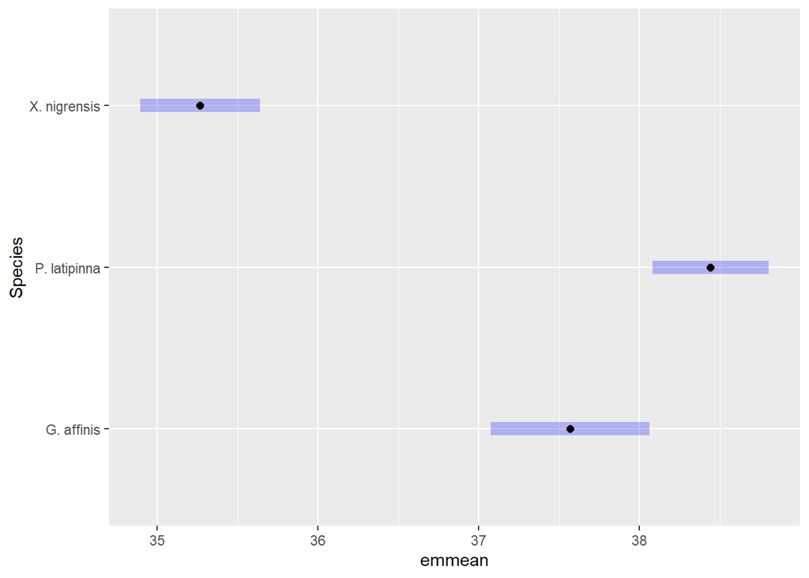

```r
model.1red %>%
  emmeans(pairwise~Species) %>%
  plot() #will plot group means with 95% confidence intervals
```

```r
model.1red %>%
  emmeans(pairwise~Sex) %>%
  summary()
```

```
## $emmeans
##  Sex    emmean    SE df lower.CL upper.CL
##  female   37.0 0.168 75     36.6     37.3
##  male     37.2 0.165 75     36.9     37.6
##
## Results are averaged over the levels of: Species
## Confidence level used: 0.95
##
## $contrasts
##  contrast      estimate    SE df t.ratio p.value
##  female - male   -0.284 0.231 75  -1.229  0.2227
##
## Results are averaged over the levels of: Species
```

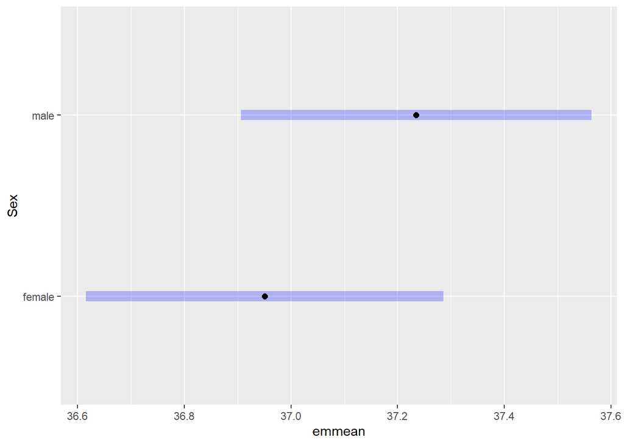

```r
model.1red %>%
  emmeans(pairwise~Sex) %>%
  plot()
```

### CTmin

Repeat above for CTmin

```r
#full model with interaction
model.2a <- glm(CTmin.C ~ Sex * Species + Size.mm, data = rawTempData)


#reduced model without interaction
model.2b <- glm(CTmin.C ~ Sex + Species + Size.mm, data = rawTempData)

#Test for significance of the interaction term (fixed effects)
model.sel(model.2a, model.2b)
```

```
## Model selection table
##          (Int) Sex   Siz.mm Spc Sex:Spc df   logLik  AICc delta weight
## model.2b 5.584   + -0.02921   +          6 -137.071 287.3  0.00  0.915
## model.2a 5.818   + -0.03506   +       +  8 -137.004 292.1  4.76  0.085
## Models ranked by AICc(x)
```

```r
  ##model.2b selected


#check that Size.mm size improves our model
model.2red <- glm(CTmin.C ~ Sex + Species, data=rawTempData)

model.sel(model.2b, model.2red)
```

```
## Model selection table
##            (Int) Sex   Siz.mm Spc df   logLik  AICc delta weight
## model.2red 4.827   +            +  5 -137.434 285.7  0.00  0.692
## model.2b   5.584   + -0.02921   +  6 -137.071 287.3  1.62  0.308
## Models ranked by AICc(x)
```

```r
  ##model.2red selected
```

#### Summary of final chosen model

```r
summary(model.2red)
```

```
##
## Call:
## glm(formula = CTmin.C ~ Sex + Species, data = rawTempData)
##
## Coefficients:
##                     Estimate Std. Error t value Pr(>|t|)
## (Intercept)           4.8272     0.3822  12.629  < 2e-16 ***
## Sexmale               0.2298     0.3184   0.722    0.473
## SpeciesP. latipinna   1.9416     0.4246   4.573 1.86e-05 ***
## SpeciesX. nigrensis   4.9174     0.4295  11.450  < 2e-16 ***
## ---
## Signif. codes:  0 '***' 0.001 '**' 0.01 '*' 0.05 '.' 0.1 ' ' 1
##
## (Dispersion parameter for gaussian family taken to be 2.00057)
##
##     Null deviance: 440.15  on 78  degrees of freedom
## Residual deviance: 150.04  on 75  degrees of freedom
## AIC: 284.87
##
## Number of Fisher Scoring iterations: 2
```

```r
#this may give you an error, since there's been a change in the syntax for the lme4 package since version 4.1.2. If you get an error, remove the '#' and run the code below
## summary(full, use.hessian = FALSE)

model.2red %>%
  emmeans(pairwise~Species) %>%
  summary() #will display estimates and pairwise comparisons
```

```
## $emmeans
##  Species      emmean    SE df lower.CL upper.CL
##  G. affinis     4.94 0.343 75     4.26     5.63
##  P. latipinna   6.88 0.250 75     6.39     7.38
##  X. nigrensis   9.86 0.258 75     9.35    10.37
##
## Results are averaged over the levels of: Sex
## Confidence level used: 0.95
##
## $contrasts
##  contrast                    estimate    SE df t.ratio p.value
##  G. affinis - P. latipinna      -1.94 0.425 75  -4.573  0.0001
##  G. affinis - X. nigrensis      -4.92 0.429 75 -11.450  <.0001
##  P. latipinna - X. nigrensis    -2.98 0.359 75  -8.279  <.0001
##
## Results are averaged over the levels of: Sex
## P value adjustment: tukey method for comparing a family of 3 estimates
```

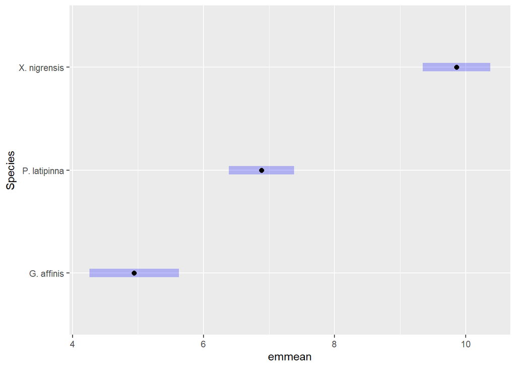

```r
model.2red %>%
  emmeans(pairwise~Species) %>%
  plot() #will plot group means with 95% confidence intervals
```

```r
model.2red %>%
  emmeans(pairwise~Sex) %>%
  summary()
```

```
## $emmeans
##  Sex    emmean    SE df lower.CL upper.CL
##  female   7.11 0.232 75     6.65     7.58
##  male     7.34 0.228 75     6.89     7.80
##
## Results are averaged over the levels of: Species
## Confidence level used: 0.95
##
## $contrasts
##  contrast      estimate    SE df t.ratio p.value
##  female - male    -0.23 0.318 75  -0.722  0.4728
##
## Results are averaged over the levels of: Species
```

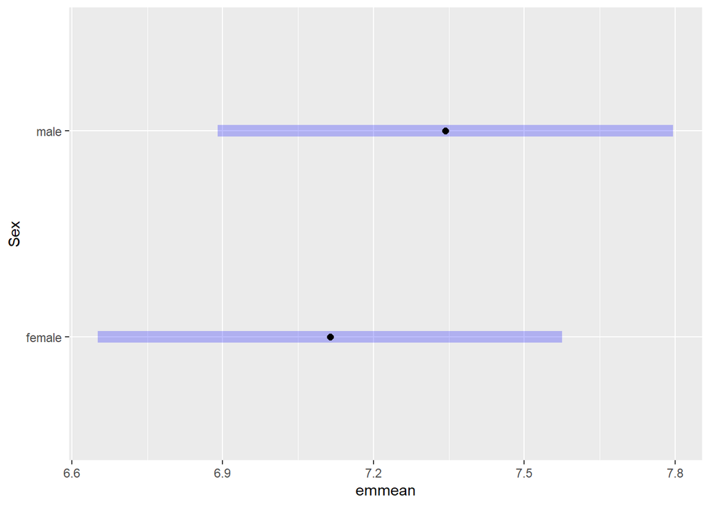

```r
model.2red %>%
  emmeans(pairwise~Sex) %>%
  plot()
```

### Tot temp

Repeat above for Tot temp

```r
#full model with interaction
model.3a <- glm(T.tot ~ Sex * Species + Size.mm, data = rawTempData)


#reduced model without interaction
model.3b <- glm(T.tot ~ Sex + Species + Size.mm, data = rawTempData)

#Test for significance of the interaction term (fixed effects)
model.sel(model.3a, model.3b)
```

```
## Model selection table
##          (Int) Sex  Siz.mm Spc Sex:Spc df   logLik  AICc delta weight
## model.3b 32.21   + 0.01491   +          6 -165.969 345.1  0.00  0.895
## model.3a 31.27   + 0.03619   +       +  8 -165.670 349.4  4.29  0.105
## Models ranked by AICc(x)
```

```r
  ##model.3b selected

#check that Size.mm size improves our model
model.3red <- glm(T.tot ~ Sex + Species, data=rawTempData)

model.sel(model.3b, model.3red)
```

```
## Model selection table
##            (Int) Sex  Siz.mm Spc df   logLik  AICc delta weight
## model.3red 32.60   +           +  5 -166.015 342.9  0.00  0.755
## model.3b   32.21   + 0.01491   +  6 -165.969 345.1  2.25  0.245
## Models ranked by AICc(x)
```

```r
  ##model.3red selected
```

#### Summary of final chosen model

```r
summary(model.3red)
```

```
##
## Call:
## glm(formula = T.tot ~ Sex + Species, data = rawTempData)
##
## Coefficients:
##                     Estimate Std. Error t value Pr(>|t|)
## (Intercept)         32.59987    0.54882  59.400   <2e-16 ***
## Sexmale              0.05413    0.45716   0.118   0.9061
## SpeciesP. latipinna -1.06795    0.60967  -1.752   0.0839 .
## SpeciesX. nigrensis -7.21952    0.61668 -11.707   <2e-16 ***
## ---
## Signif. codes:  0 '***' 0.001 '**' 0.01 '*' 0.05 '.' 0.1 ' ' 1
##
## (Dispersion parameter for gaussian family taken to be 4.124653)
##
##     Null deviance: 1113.76  on 78  degrees of freedom
## Residual deviance:  309.35  on 75  degrees of freedom
## AIC: 342.03
##
## Number of Fisher Scoring iterations: 2
```

```r
#this may give you an error, since there's been a change in the syntax for the lme4 package since version 4.1.2. If you get an error, remove the '#' and run the code below
## summary(full, use.hessian = FALSE)


model.3red %>%
  emmeans(pairwise~Species) %>%
  summary() #will display estimates and pairwise comparisons
```

```
## $emmeans
##  Species      emmean    SE df lower.CL upper.CL
##  G. affinis     32.6 0.493 75     31.6     33.6
##  P. latipinna   31.6 0.359 75     30.8     32.3
##  X. nigrensis   25.4 0.371 75     24.7     26.1
##
## Results are averaged over the levels of: Sex
## Confidence level used: 0.95
##
## $contrasts
##  contrast                    estimate    SE df t.ratio p.value
##  G. affinis - P. latipinna       1.07 0.610 75   1.752  0.1931
##  G. affinis - X. nigrensis       7.22 0.617 75  11.707  <.0001
##  P. latipinna - X. nigrensis     6.15 0.516 75  11.919  <.0001
##
## Results are averaged over the levels of: Sex
## P value adjustment: tukey method for comparing a family of 3 estimates
```

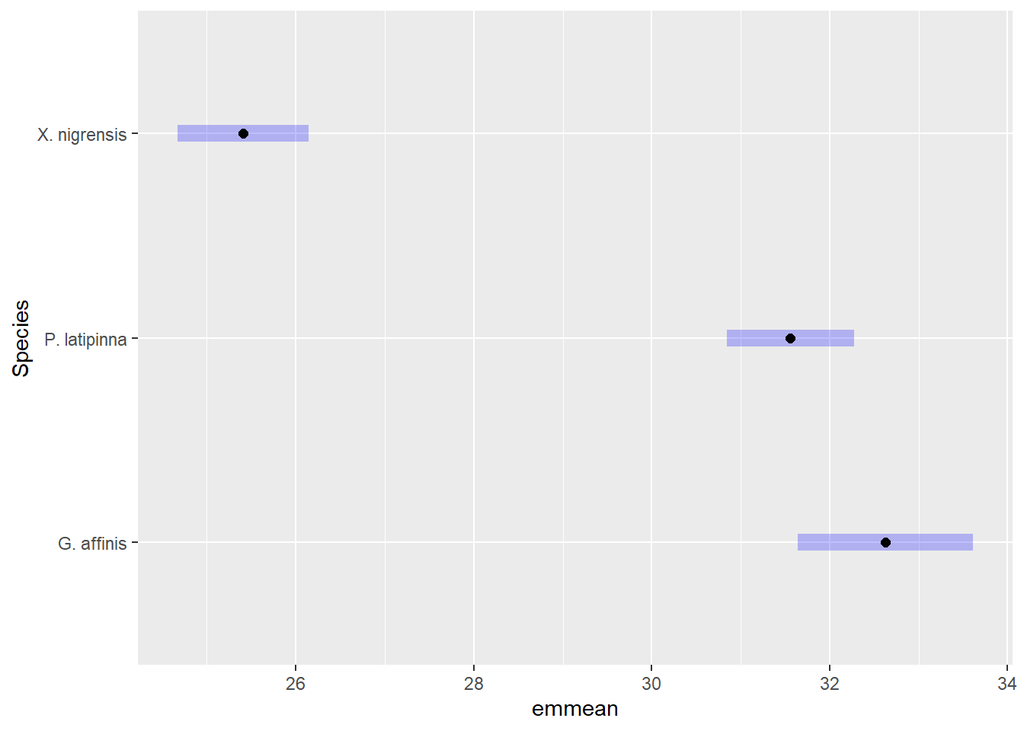

```r
model.3red %>%
  emmeans(pairwise~Species) %>%
  plot() #will plot group means with 95% confidence intervals
```

```r
model.3red %>%
  emmeans(pairwise~Sex) %>%
  summary()
```

```
## $emmeans
##  Sex    emmean    SE df lower.CL upper.CL
##  female   29.8 0.333 75     29.2     30.5
##  male     29.9 0.327 75     29.2     30.5
##
## Results are averaged over the levels of: Species
## Confidence level used: 0.95
##
## $contrasts
##  contrast      estimate    SE df t.ratio p.value
##  female - male  -0.0541 0.457 75  -0.118  0.9061
##
## Results are averaged over the levels of: Species
```

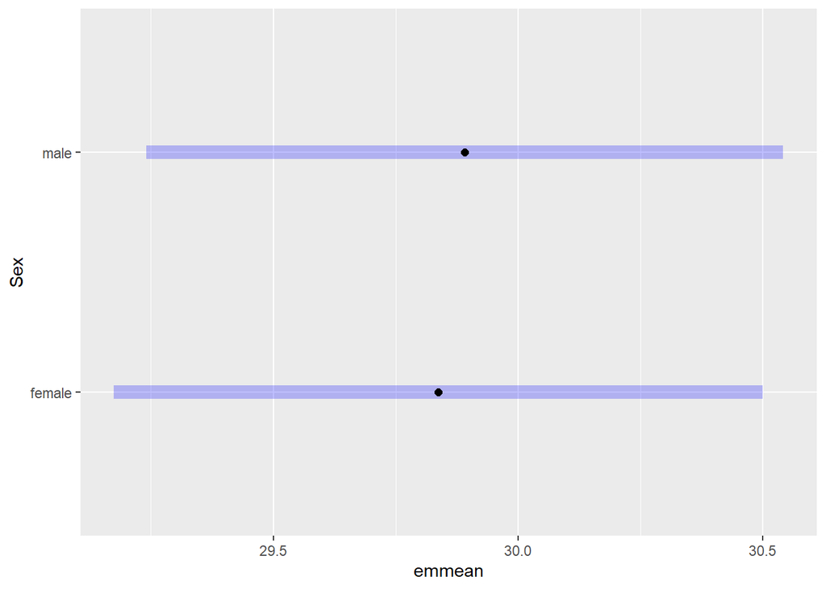

```r
model.3red %>%
  emmeans(pairwise~Sex) %>%
  plot()
```

### Check normality of final models

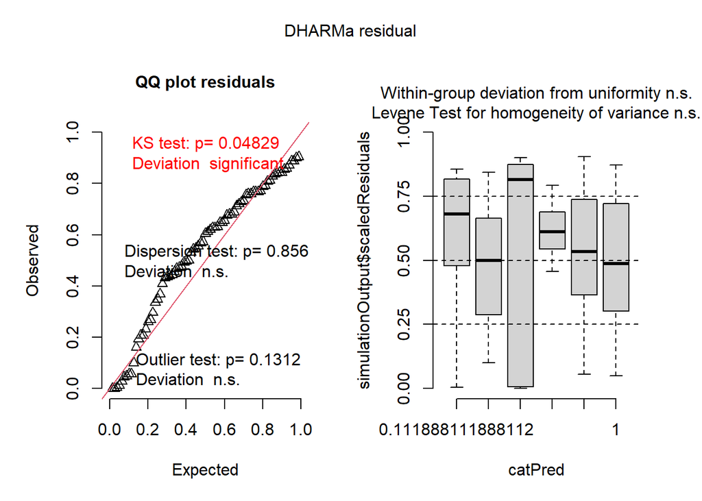

```r
############ CTmax ###########
#Simulated residuals plots using DHARMa package


simulationOutput <- simulateResiduals(model.1red)

plot(simulationOutput)
```

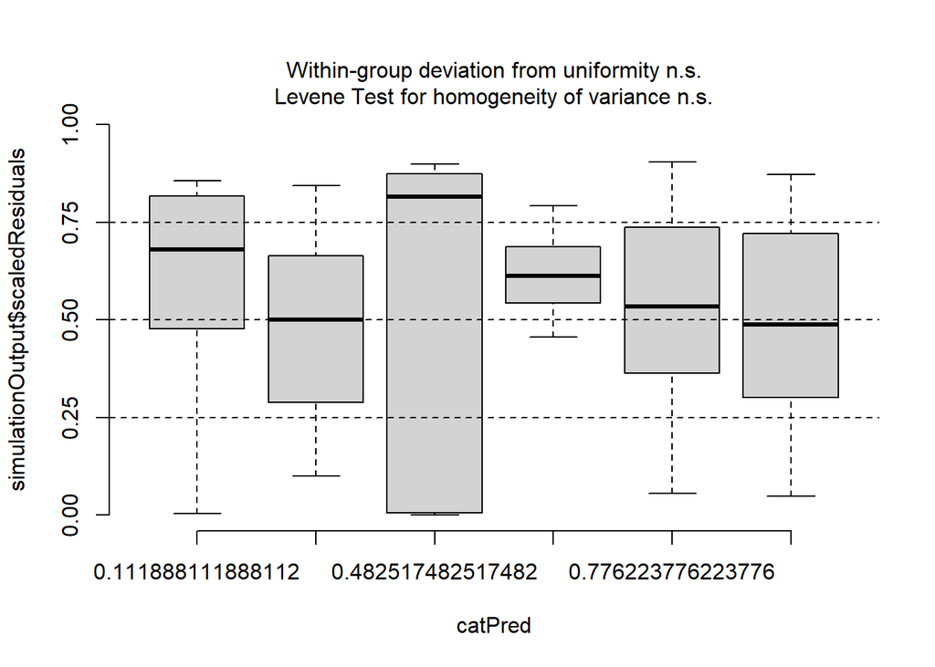

```r
plotResiduals(simulationOutput)
```

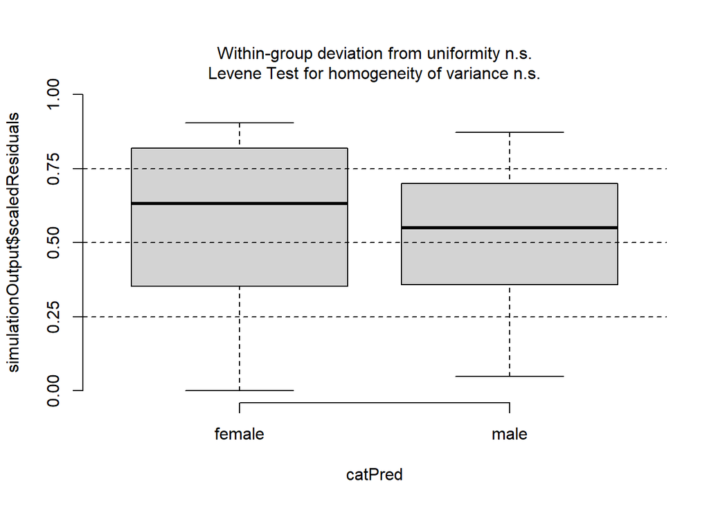

```r
plotResiduals(simulationOutput, form = rawTempData$Sex)
```

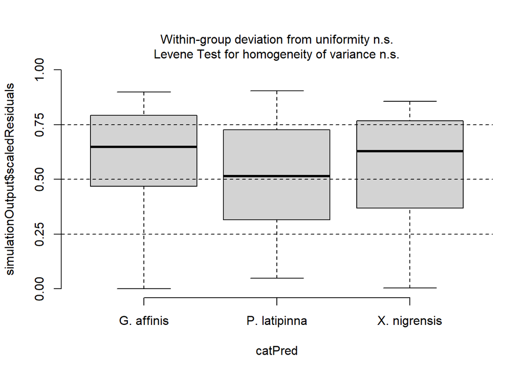

```r
plotResiduals(simulationOutput, form = rawTempData$Species)
```

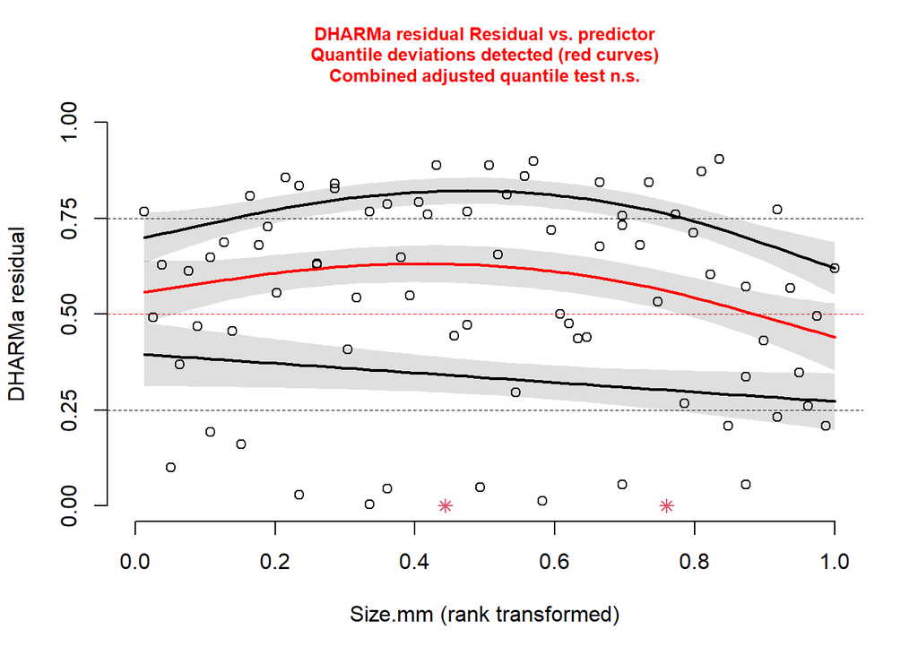

```r
plotResiduals(simulationOutput, form = rawTempData$Size.mm)
```

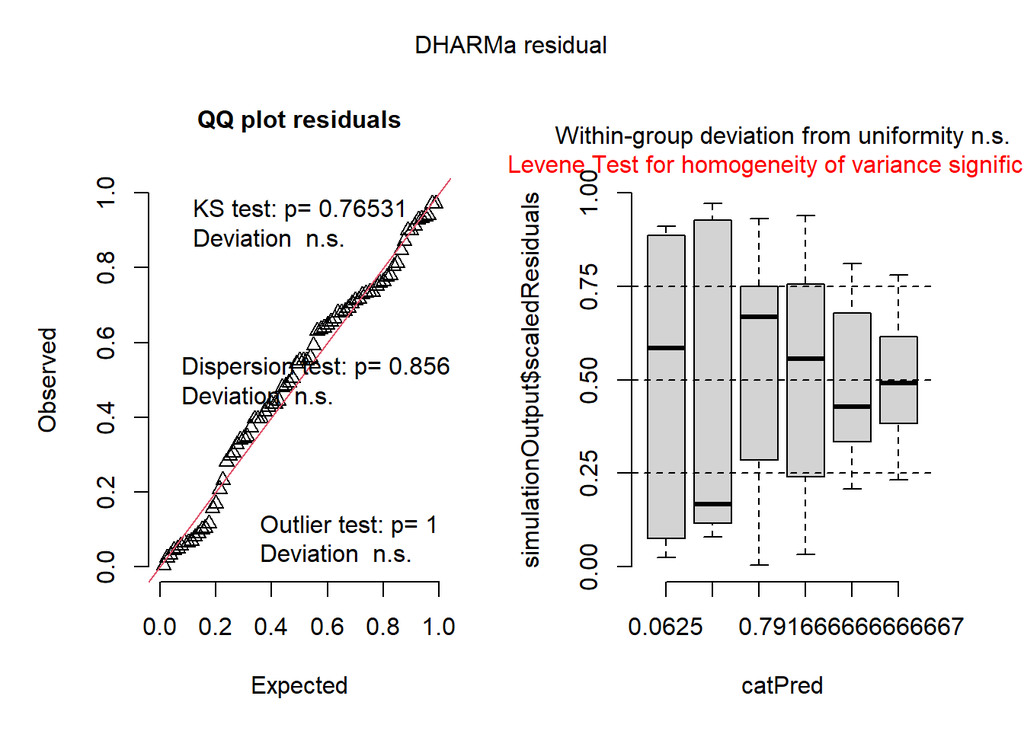

```r
  ###KS significant


########### CTmin ###########
#Simulated residuals plots using DHARMa package

simulationOutput <- simulateResiduals(model.2red)

plot(simulationOutput)
```

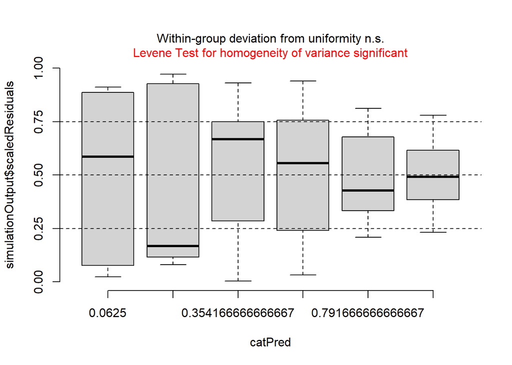

```r
plotResiduals(simulationOutput)
```

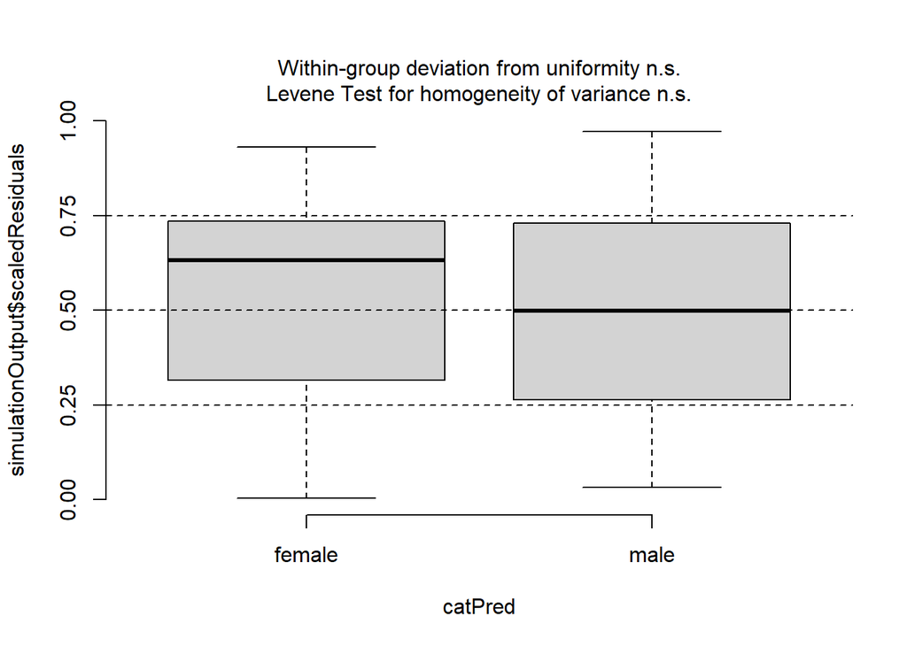

```r
plotResiduals(simulationOutput, form = rawTempData$Sex)
```

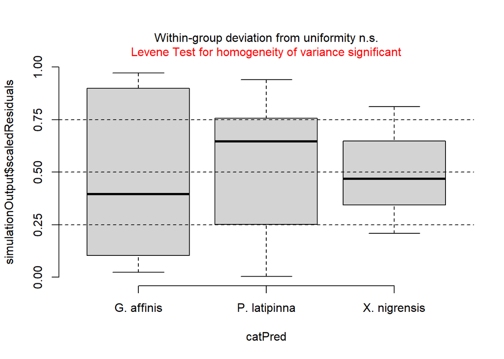

```r
plotResiduals(simulationOutput, form = rawTempData$Species)
```

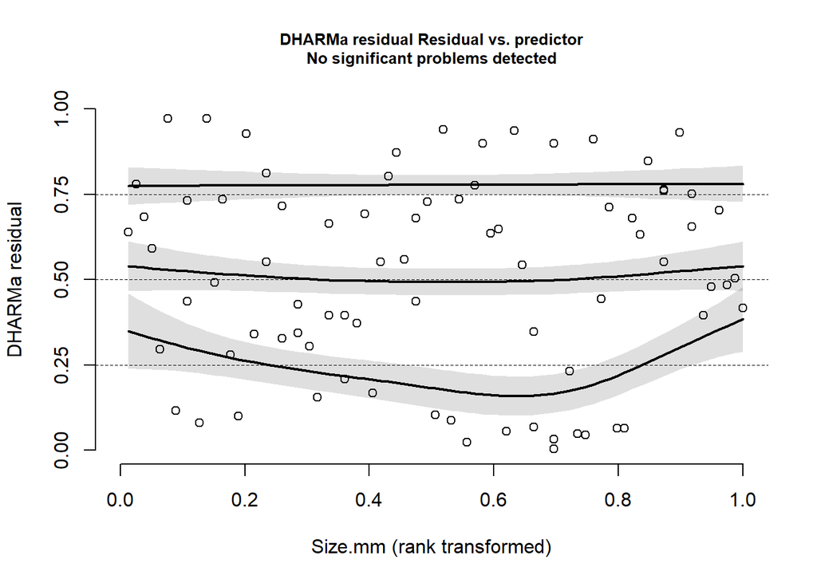

```r
plotResiduals(simulationOutput, form = rawTempData$Size.mm)
```

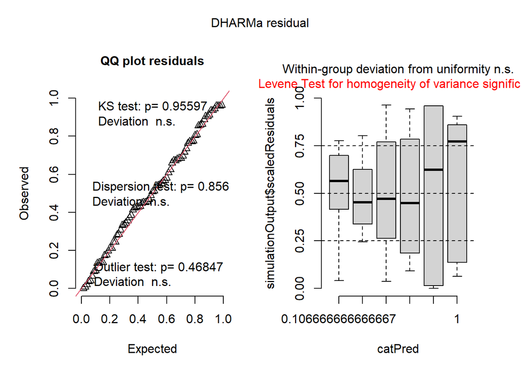

```r
  ###Levene's test significant

########### Tottemp ###########
#Simulated residuals plots using DHARMa package


simulationOutput <- simulateResiduals(model.3red)

plot(simulationOutput)
```

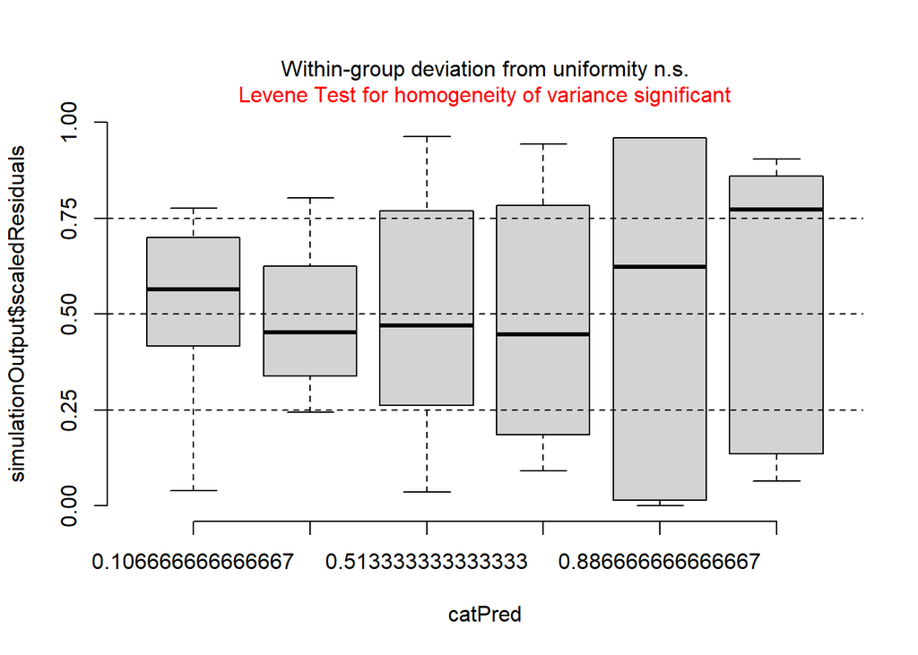

```r
plotResiduals(simulationOutput)
```

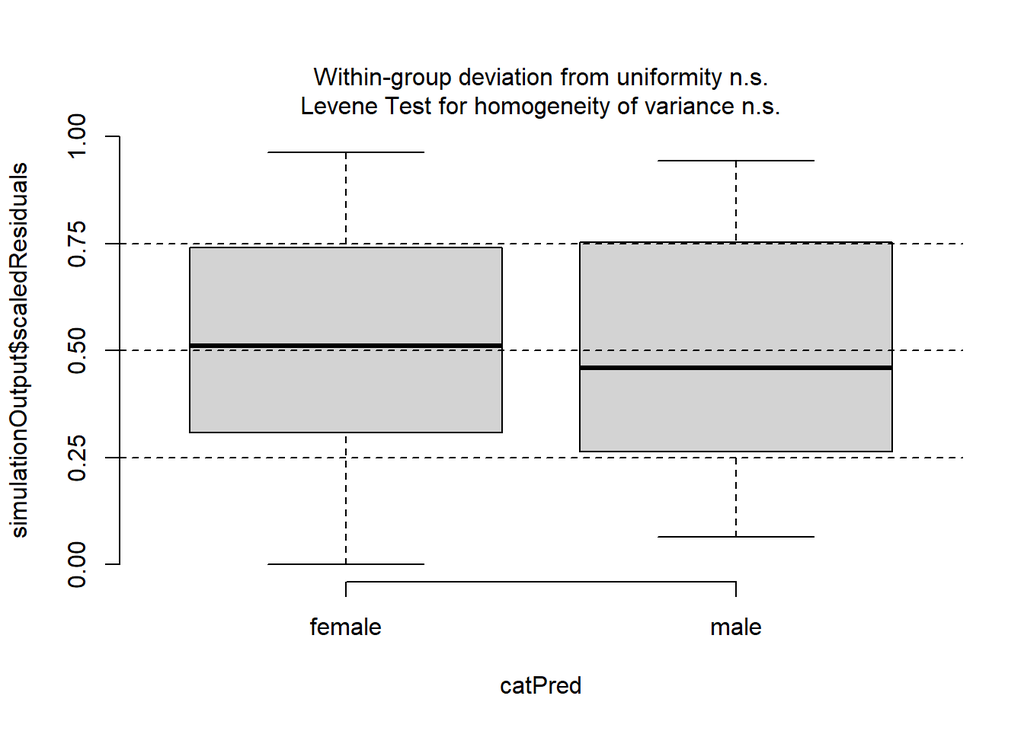

```r
plotResiduals(simulationOutput, form = rawTempData$Sex)
```

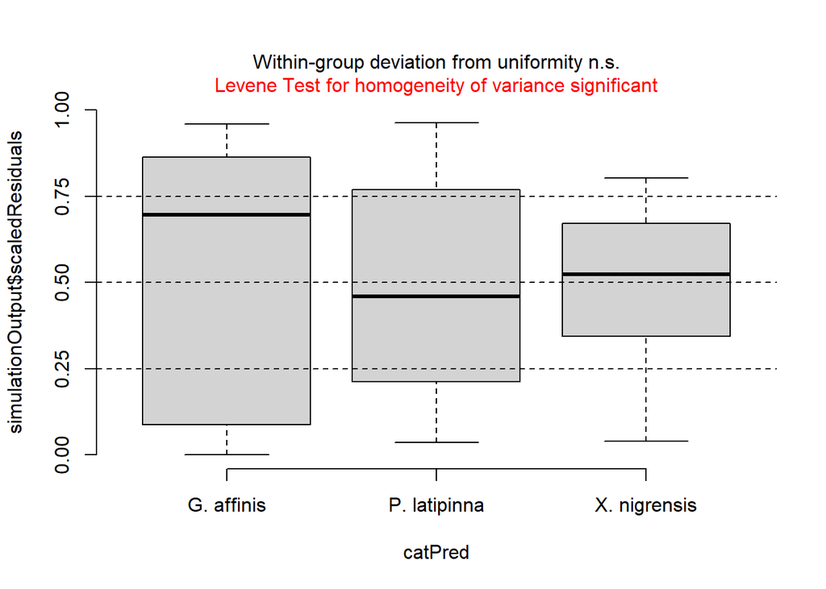

```r
plotResiduals(simulationOutput, form = rawTempData$Species)
```

```
## qu = 0.75, log(sigma) = -2.934 : outer Newton did not converge fully.
```

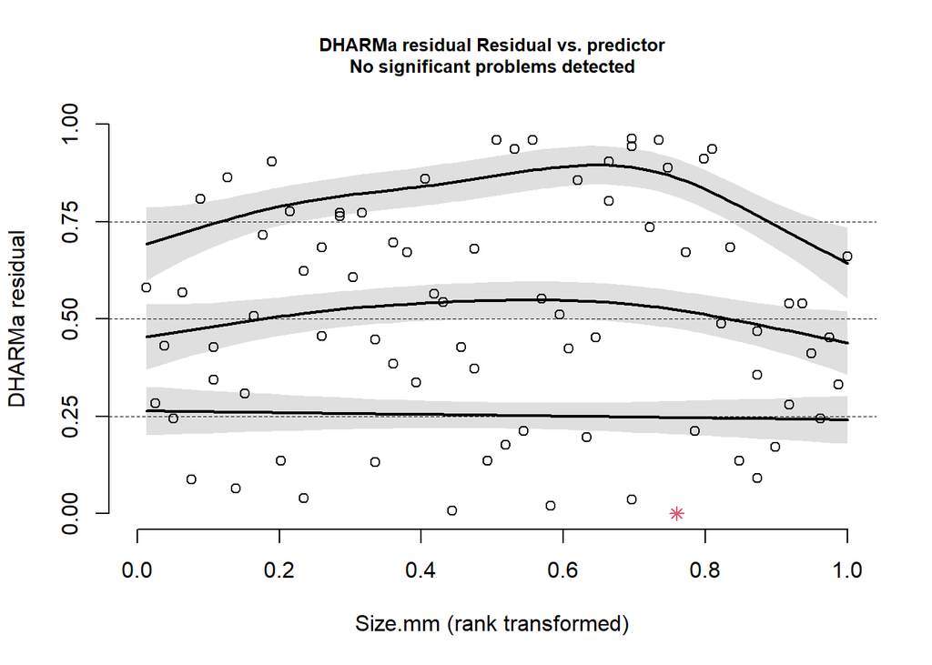

```r
plotResiduals(simulationOutput, form = rawTempData$Size.mm)
```

```r
  ###Levene's test significant
```

#### Residual corrections

Model 1 (CTmax) residuals did not conform to normality (failed KS test). Model 2 and 3 (CTmin and total temperature) residuals are normal but heteroscedastic. Will first calculate robust standard errors to interpret results.

An alternative approach: Create a bootstrapped model for all three models.

An alternative approach: Create a bootstrapped model for model 1, and weight least squares model followed by another DHARMa check for models 2 and 3.

```r
######### Model 1 ##########

library(sandwich)
library(lmtest)
#Robust inference for heteroscedasticity and non-normality
coeftest(model.1red, vcov=vcovHC(model.1red, type = "HC3"))
```

```
##
## z test of coefficients:
##
##                     Estimate Std. Error z value  Pr(>|z|)
## (Intercept)         37.42706    0.42973 87.0944 < 2.2e-16 ***
## Sexmale              0.28389    0.24320  1.1673   0.24309
## SpeciesP. latipinna  0.87365    0.37651  2.3204   0.02032 *
## SpeciesX. nigrensis -2.30209    0.39506 -5.8271  5.64e-09 ***
## ---
## Signif. codes:  0 '***' 0.001 '**' 0.01 '*' 0.05 '.' 0.1 ' ' 1
```

```r
coeftest(model.2red, vcov=vcovHC(model.2red, type = "HC3"))
```

```
##
## z test of coefficients:
##
##                     Estimate Std. Error z value  Pr(>|z|)
## (Intercept)          4.82719    0.54344  8.8827 < 2.2e-16 ***
## Sexmale              0.22976    0.32850  0.6994 0.4842963
## SpeciesP. latipinna  1.94161    0.58612  3.3127 0.0009241 ***
## SpeciesX. nigrensis  4.91743    0.53156  9.2510 < 2.2e-16 ***
## ---
## Signif. codes:  0 '***' 0.001 '**' 0.01 '*' 0.05 '.' 0.1 ' ' 1
```

```r
coeftest(model.3red, vcov=vcovHC(model.3red, type = "HC3"))
```

```
##
## z test of coefficients:
##
##                      Estimate Std. Error z value Pr(>|z|)
## (Intercept)         32.599873   0.876204 37.2058   <2e-16 ***
## Sexmale              0.054128   0.478756  0.1131   0.9100
## SpeciesP. latipinna -1.067953   0.847614 -1.2600   0.2077
## SpeciesX. nigrensis -7.219521   0.797187 -9.0562   <2e-16 ***
## ---
## Signif. codes:  0 '***' 0.001 '**' 0.01 '*' 0.05 '.' 0.1 ' ' 1
```

##### Interpretation of results

The **estimate** represents the effect size or coefficient of a predictor (e.g. sex or species) on the response variable (temp in our case). For linear models (e.g. GLM with family=gaussian), the estimate the change in the response variable associated with a one-unit change in the predictor, holding all other predictors constant. For example, if the coefficient for speciesB is 2.45 it means that speciesB is associated with a 2.45 higher temperature compared to the reference species (speciesA), assuming all other predictors are held constant (e.g. female to female).

The **standard error** meaures the variability or uncertainty of the coefficient estimate. It quantifies how much the estimate would vary if you repeated the study many times with different samples. A smaller SE means the coefficient estimate is more precise. A large SE suggests greater uncertanty, which can result from small sample sizes, high variability in the data, or multicollinearity (predictors being highly correlated). The SE is used to compute the **z-value** and confidence intervals, which help assess whether the cofficient is significantly different from zero.

The **z-value** (aka test statistic) is the ratio of the estimate to its standard error. It shows how many standard errors the estimate is away from zero (the null hypothesis value). A larger absolute z-value indicates stronger evidence against the null hypothesis.

To interpret the output:

The **intercept** is the baseline value of temp when all predictors are at their reference levels (e.g. sex=female, species=A). **Sexmale** estimate indicates that being male increases/decreases the predictd temperature by the estimated units compared to females. However, check that the p-value is significant to indicate whether this is a significant change. **SpeciesB** and **SpeciesC** estimate indicates that being a different species increases/decreases the predicted temperature by the estimated units compared to being SpeciesA, when all are the same sex (ie other parameters held constant).

### Interpret and visualize model results

```r
#to interpret model results

##CTmax
get_model_data(model.1red,type="pred", terms = c("Sex", "Species"))
```

```
## # Predicted values of CTmax.C
##
## Species: G. affinis
##
## Sex | Predicted |       95% CI |  group_col
## -------------------------------------------
##   1 |     37.43 | 36.87, 37.98 | G. affinis
##   2 |     37.71 | 37.17, 38.25 | G. affinis
##
## Species: P. latipinna
##
## Sex | Predicted |       95% CI |    group_col
## ---------------------------------------------
##   1 |     38.30 | 37.87, 38.73 | P. latipinna
##   2 |     38.58 | 38.16, 39.01 | P. latipinna
##
## Species: X. nigrensis
##
## Sex | Predicted |       95% CI |    group_col
## ---------------------------------------------
##   1 |     35.12 | 34.69, 35.56 | X. nigrensis
##   2 |     35.41 | 34.97, 35.85 | X. nigrensis
```

```r
##CTmin
get_model_data(model.2red,type="pred", terms = c("Sex", "Species"))
```

```
## # Predicted values of CTmin.C
##
## Species: G. affinis
##
## Sex | Predicted |      95% CI |  group_col
## ------------------------------------------
##   1 |      4.83 | 4.07,  5.59 | G. affinis
##   2 |      5.06 | 4.31,  5.80 | G. affinis
##
## Species: P. latipinna
##
## Sex | Predicted |      95% CI |    group_col
## --------------------------------------------
##   1 |      6.77 | 6.18,  7.36 | P. latipinna
##   2 |      7.00 | 6.41,  7.59 | P. latipinna
##
## Species: X. nigrensis
##
## Sex | Predicted |      95% CI |    group_col
## --------------------------------------------
##   1 |      9.74 | 9.14, 10.35 | X. nigrensis
##   2 |      9.97 | 9.37, 10.58 | X. nigrensis
```

```r
##Tot temp
get_model_data(model.3red,type="pred", terms = c("Sex", "Species"))
```

```
## # Predicted values of T.tot
##
## Species: G. affinis
##
## Sex | Predicted |       95% CI |  group_col
## -------------------------------------------
##   1 |     32.60 | 31.51, 33.69 | G. affinis
##   2 |     32.65 | 31.58, 33.72 | G. affinis
##
## Species: P. latipinna
##
## Sex | Predicted |       95% CI |    group_col
## ---------------------------------------------
##   1 |     31.53 | 30.68, 32.38 | P. latipinna
##   2 |     31.59 | 30.74, 32.43 | P. latipinna
##
## Species: X. nigrensis
##
## Sex | Predicted |       95% CI |    group_col
## ---------------------------------------------
##   1 |     25.38 | 24.51, 26.25 | X. nigrensis
##   2 |     25.43 | 24.57, 26.30 | X. nigrensis
```

#### Plot results

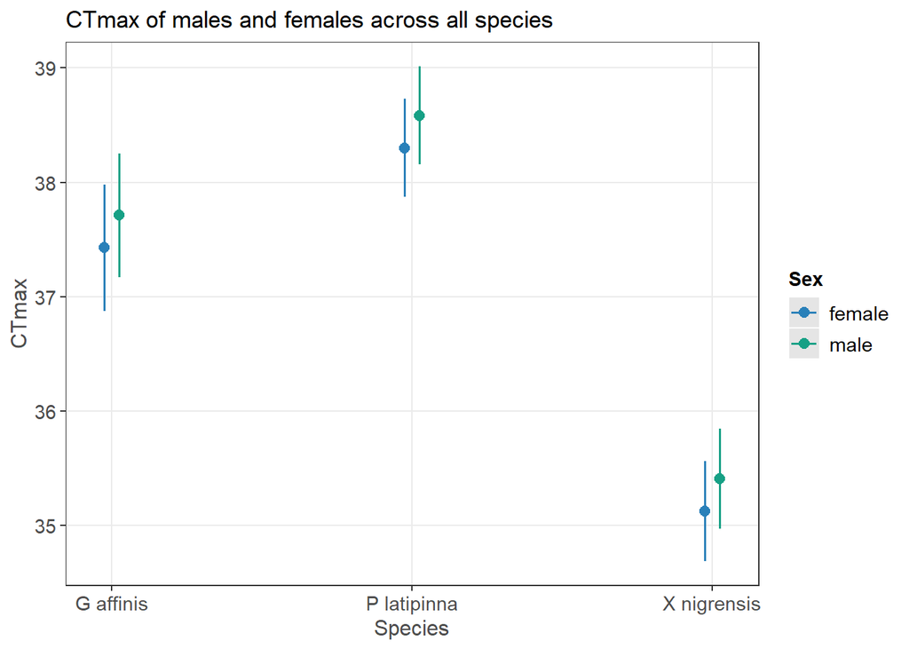

```r
############## CTmax ############
set_theme(base = theme_bw(), panel.minor.gridcol = 'white')

##using the type="pred" parameter allows us to visualize how specific terms affect our outcome variable. This will create a graph with species on the x, CTmax on the y, and two lines for sex
CTMAX_results <- plot_model(model.1red,
             type = "pred",
             terms = c("Species", "Sex"),
             colors=c("#2980b9", "#16a085", "#f39c12"),
             axis.title = c("Species", "CTmax"),
             legend.title = c("Sex"), title = "CTmax of males and females across all species")

CTMAX_results
```

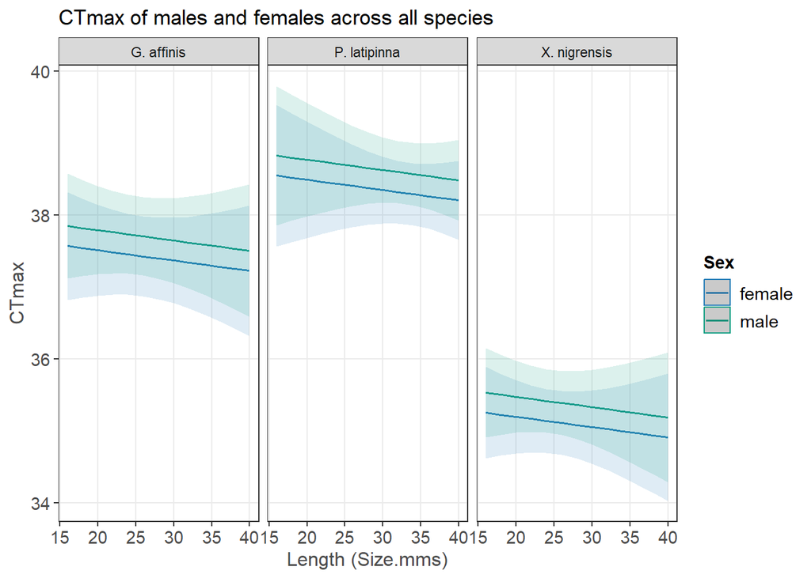

```r
#now lets also include size. This will create a figure with size as the x-axis, ctmax as the y, two predictor lines for the two sexes and different graphs/facets for each species

CTMAX_results2 <- plot_model(model.1b,
             type = "pred",
             terms = c("Size.mm", "Sex", "Species"),
             colors=c("#2980b9", "#16a085", "#f39c12"),
             axis.title = c("Length (Size.mms)", "CTmax"),
             legend.title = c("Sex"), title = "CTmax of males and females across all species")

CTMAX_results2
```

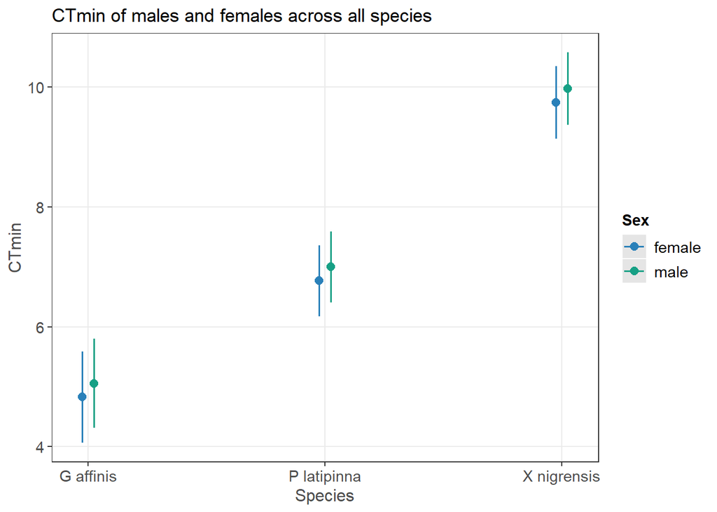

```r
############ CTmin ############
set_theme(base = theme_bw(), panel.minor.gridcol = 'white')

##using the type="pred" parameter allows us to visualize how specific terms affect our outcome variable. This will create a graph with species on the x, CTmax on the y, and two lines for sex
CTMIN_results <- plot_model(model.2red,
             type = "pred",
             terms = c("Species", "Sex"),
             colors=c("#2980b9", "#16a085", "#f39c12"),
             axis.title = c("Species", "CTmin"),
             legend.title = c("Sex"), title = "CTmin of males and females across all species")

CTMIN_results
```

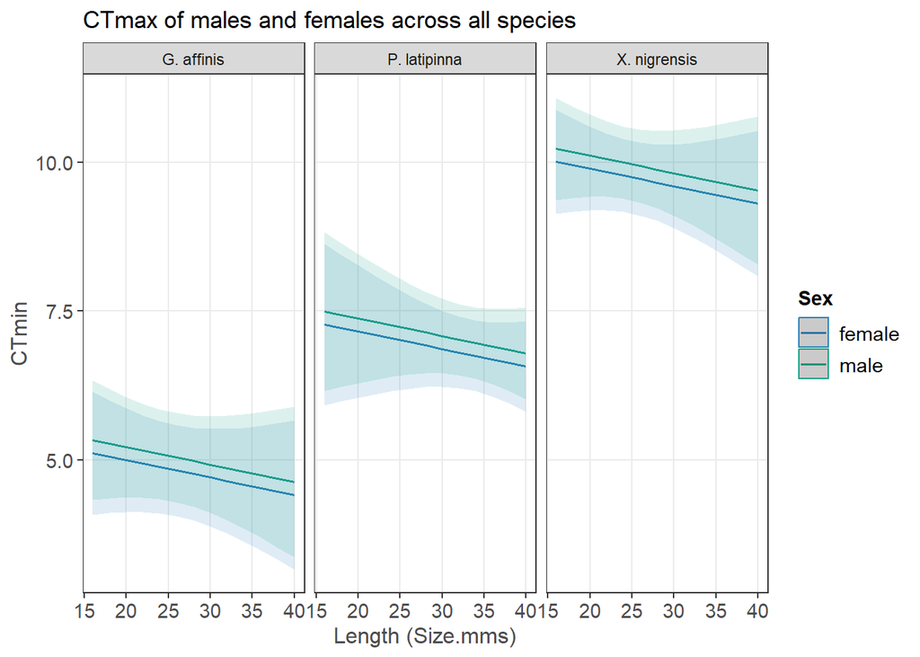

```r
#now lets also include size. This will create a figure with size as the x-axis, ctmax as the y, two predictor lines for the two sexes and different graphs/facets for each species

CTMIN_results2 <- plot_model(model.2b,
             type = "pred",
             terms = c("Size.mm", "Sex", "Species"),
             colors=c("#2980b9", "#16a085", "#f39c12"),
             axis.title = c("Length (Size.mms)", "CTmin"),
             legend.title = c("Sex"), title = "CTmax of males and females across all species")

CTMIN_results2
```

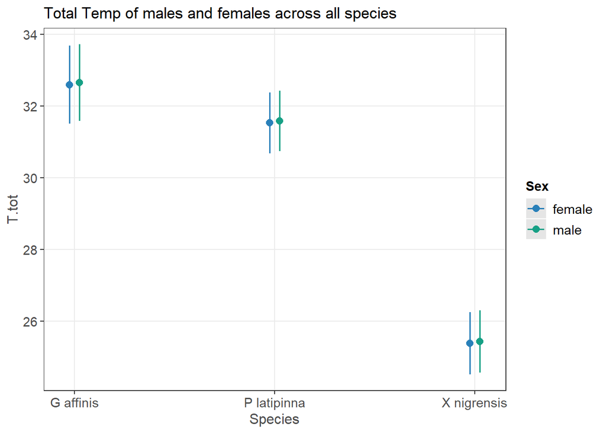

```r
############## Tot temp ############
set_theme(base = theme_bw(), panel.minor.gridcol = 'white')

##using the type="pred" parameter allows us to visualize how specific terms affect our outcome variable. This will create a graph with species on the x, CTmax on the y, and two lines for sex
TTEMP_results <- plot_model(model.3red,
             type = "pred",
             terms = c("Species", "Sex"),
             colors=c("#2980b9", "#16a085", "#f39c12"),
             axis.title = c("Species", "T.tot"),
             legend.title = c("Sex"), title = "Total Temp of males and females across all species")

TTEMP_results
```

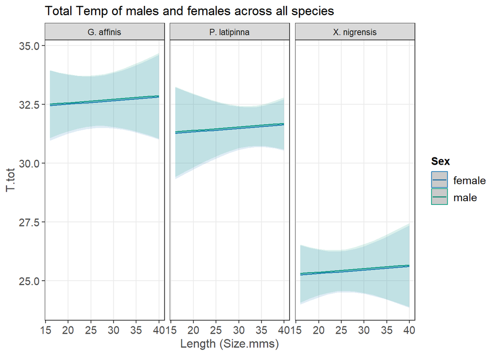

```r
#now lets also include size. This will create a figure with size as the x-axis, ctmax as the y, two predictor lines for the two sexes and different graphs/facets for each species

TTEMP_results2 <- plot_model(model.3b,
             type = "pred",
             terms = c("Size.mm", "Sex", "Species"),
             colors=c("#2980b9", "#16a085", "#f39c12"),
             axis.title = c("Length (Size.mms)", "T.tot"),
             legend.title = c("Sex"), title = "Total Temp of males and females across all species")

TTEMP_results2
```

### Question 1 results

Models that were used (WITHOUT INTERACTION): model.1red, model.2red, model.3red.

CTMAX - highest max temps found in P. latipinna and lowest max temps in X. nigrensis - Highest temps in P. latipinna at 39 deg C - Lowest temps in X. nigrensis at around 34.5 deg C - no significant difference between males and females, but species significantly differ

CTMIN - lowest min temp in G. affinis at 4.5 deg C and highest min temps in X. nigrensis at around 10 deg C - no significant difference between males and females, but species significantly differ

TOT.TEMP - highest total temperatures that all our target fish could have was found in G. affinis from 32 to almost 34 deg C - lowesst total temp range found in X. nigrensis at around 25 deg C - again, no significant difference between males and females - total thermal range between G. affinis and P. latipinna are not significantly different, but both are significantly different to the total thermal range of X. nigrensis.

## Question 2

Regardless of the size differences, do the two males and female of the swordtail species differ in their thermal tolerance (max, min, tot) due to mating strategies?

```r
swordtail_1 <- rawTempData[rawTempData$Species =="X. nigrensis",]
```

Also, since females don’t have a mating strategy, and the size of males corresponds with their mating strategy (large=courting, small=coercive), I think it would be best/easiest for our model to create a new sex column with three factors: female, male.large, and male.small. That way we won’t have to worry about one of our groups (ie females) not having a factor for mating strategy. SO let’s create a new column. The size.cat column is basically what we want, since it has a value for the two males and for females, but let’s make some more intuitive labels.

```r
swordtail_1$sex.2 <- swordtail_1$Size.cat #duplicates column

#replace values in new column
swordtail_1$sex.2 <- gsub("large", "male.large", swordtail_1$sex.2)
swordtail_1$sex.2 <- gsub("small", "male.small", swordtail_1$sex.2)
swordtail_1$sex.2 <- gsub("reg", "female", swordtail_1$sex.2)


#added as character, changing to factor

swordtail_1$sex.2 <- as.factor(swordtail_1$sex.2)
```

Now for the model

### CTmax

Remember, to address mating style and sex we’ll use the new column, sex.2

```r
#wfull model with size; NOTE: there is no interaction effect here, since sex and mating style are just one factor now.

model.4a <- glm(CTmax.C ~ sex.2 + Size.mm, data = swordtail_1)



#reduced model without size

model.4b <- glm(CTmax.C ~ sex.2, data = swordtail_1)

#Model selection
model.sel(model.4a, model.4b)
```

```
## Model selection table
##          (Int) sex.2  Siz.mm df  logLik AICc delta weight
## model.4b 35.17     +          4 -42.118 93.8  0.00  0.689
## model.4a 37.67     + -0.1082  5 -41.464 95.4  1.59  0.311
## Models ranked by AICc(x)
```

```r
  ##model.4b selected
```

#### Summary of final chosen model

```r
## replace A with either the full or reduced model name
summary(model.4b)
```

```
##
## Call:
## glm(formula = CTmax.C ~ sex.2, data = swordtail_1)
##
## Coefficients:
##                  Estimate Std. Error t value Pr(>|t|)
## (Intercept)     35.171333   0.268113 131.181   <2e-16 ***
## sex.2male.large  0.418667   0.475313   0.881    0.386
## sex.2male.small -0.007896   0.454607  -0.017    0.986
## ---
## Signif. codes:  0 '***' 0.001 '**' 0.01 '*' 0.05 '.' 0.1 ' ' 1
##
## (Dispersion parameter for gaussian family taken to be 1.078266)
##
##     Null deviance: 30.067  on 29  degrees of freedom
## Residual deviance: 29.113  on 27  degrees of freedom
## AIC: 92.236
##
## Number of Fisher Scoring iterations: 2
```

```r
#this may give you an error, since there's been a change in the syntax for the lme4 package since version 4.1.2. If you get an error, remove the '#' and run the code below
## summary(full, use.hessian = FALSE)

model.4b %>%
  emmeans(pairwise~sex.2) %>%
  summary()
```

```
## $emmeans
##  sex.2      emmean    SE df lower.CL upper.CL
##  female       35.2 0.268 27     34.6     35.7
##  male.large   35.6 0.392 27     34.8     36.4
##  male.small   35.2 0.367 27     34.4     35.9
##
## Confidence level used: 0.95
##
## $contrasts
##  contrast                estimate    SE df t.ratio p.value
##  female - male.large      -0.4187 0.475 27  -0.881  0.6568
##  female - male.small       0.0079 0.455 27   0.017  0.9998
##  male.large - male.small   0.4266 0.537 27   0.794  0.7100
##
## P value adjustment: tukey method for comparing a family of 3 estimates
```

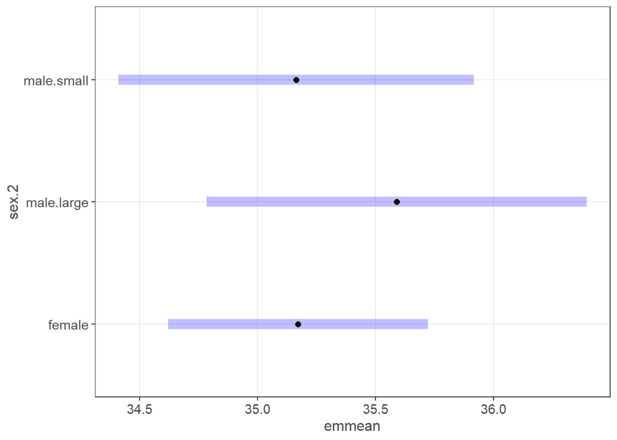

```r
model.4b %>%
  emmeans(pairwise~sex.2) %>%
  plot() #will plot group means with 95% confidence intervals
```

### CTmin

Repeat above for CTmin

```r
#full model with size; NOTE: there is no interaction effect here, since sex and mating style are just one factor now.

model.5a <- glm(CTmin.C ~ sex.2 + Size.mm, data = swordtail_1)



#reduced model without size

model.5b <- glm(CTmin.C ~ sex.2, data = swordtail_1)

#Model selection
model.sel(model.5a, model.5b)
```

```
## Model selection table
##           (Int) sex.2   Siz.mm df  logLik AICc delta weight
## model.5b  9.734     +           4 -28.705 67.0  0.00  0.694
## model.5a 11.300     + -0.06791  5 -28.076 68.7  1.64  0.306
## Models ranked by AICc(x)
```

```r
  ##model.5b selected
```

#### Summary of final chosen model

```r
## replace A with either the full or reduced model name
summary(model.5b)
```

```
##
## Call:
## glm(formula = CTmin.C ~ sex.2, data = swordtail_1)
##
## Coefficients:
##                 Estimate Std. Error t value Pr(>|t|)
## (Intercept)      9.73433    0.17145  56.775   <2e-16 ***
## sex.2male.large  0.07138    0.30396   0.235    0.816
## sex.2male.small  0.40692    0.29071   1.400    0.173
## ---
## Signif. codes:  0 '***' 0.001 '**' 0.01 '*' 0.05 '.' 0.1 ' ' 1
##
## (Dispersion parameter for gaussian family taken to be 0.4409478)
##
##     Null deviance: 12.796  on 29  degrees of freedom
## Residual deviance: 11.906  on 27  degrees of freedom
## AIC: 65.411
##
## Number of Fisher Scoring iterations: 2
```

```r
#this may give you an error, since there's been a change in the syntax for the lme4 package since version 4.1.2. If you get an error, remove the '#' and run the code below
## summary(full, use.hessian = FALSE)


model.5b %>%
  emmeans(pairwise~sex.2) %>%
  summary()
```

```
## $emmeans
##  sex.2      emmean    SE df lower.CL upper.CL
##  female       9.73 0.171 27     9.38     10.1
##  male.large   9.81 0.251 27     9.29     10.3
##  male.small  10.14 0.235 27     9.66     10.6
##
## Confidence level used: 0.95
##
## $contrasts
##  contrast                estimate    SE df t.ratio p.value
##  female - male.large      -0.0714 0.304 27  -0.235  0.9701
##  female - male.small      -0.4069 0.291 27  -1.400  0.3552
##  male.large - male.small  -0.3355 0.344 27  -0.976  0.5978
##
## P value adjustment: tukey method for comparing a family of 3 estimates
```

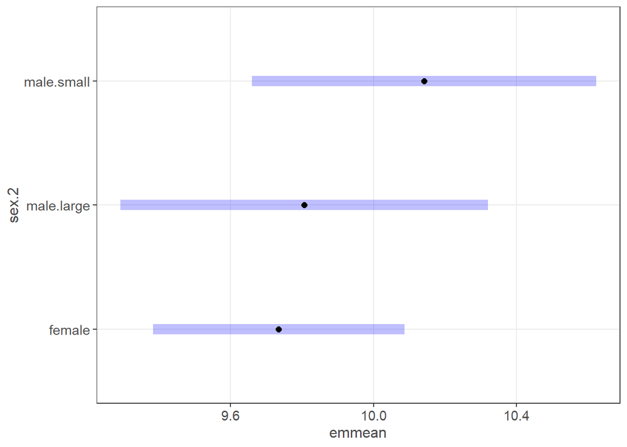

```r
model.5b %>%
  emmeans(pairwise~sex.2) %>%
  plot() #will plot group means with 95% confidence intervals
```

### Tot temp

Repeat above for Tot temp

```r
#full model with size; NOTE: there is no interaction effect here, since sex and mating style are just one factor now.

model.6a <- glm(T.tot ~ sex.2 + Size.mm, data = swordtail_1)



#reduced model without size

model.6b <- glm(T.tot ~ sex.2, data = swordtail_1)

#Model selection
model.sel(model.6a, model.6b)
```

```
## Model selection table
##          (Int) sex.2   Siz.mm df  logLik  AICc delta weight
## model.6b 25.44     +           4 -46.602 102.8  0.00    0.8
## model.6a 26.37     + -0.04034  5 -46.536 105.6  2.77    0.2
## Models ranked by AICc(x)
```

```r
  ##model.6b selected
```

#### Summary of final chosen model

```r
## replace A with either the full or reduced model name
summary(model.6b)
```

```
##
## Call:
## glm(formula = T.tot ~ sex.2, data = swordtail_1)
##
## Coefficients:
##                 Estimate Std. Error t value Pr(>|t|)
## (Intercept)      25.4370     0.3113  81.702   <2e-16 ***
## sex.2male.large   0.3473     0.5519   0.629    0.535
## sex.2male.small  -0.4148     0.5279  -0.786    0.439
## ---
## Signif. codes:  0 '***' 0.001 '**' 0.01 '*' 0.05 '.' 0.1 ' ' 1
##
## (Dispersion parameter for gaussian family taken to be 1.453982)
##
##     Null deviance: 41.452  on 29  degrees of freedom
## Residual deviance: 39.258  on 27  degrees of freedom
## AIC: 101.2
##
## Number of Fisher Scoring iterations: 2
```

```r
#this may give you an error, since there's been a change in the syntax for the lme4 package since version 4.1.2. If you get an error, remove the '#' and run the code below
## summary(full, use.hessian = FALSE)


model.6b %>%
  emmeans(pairwise~sex.2) %>%
  summary()
```

```
## $emmeans
##  sex.2      emmean    SE df lower.CL upper.CL
##  female       25.4 0.311 27     24.8     26.1
##  male.large   25.8 0.456 27     24.8     26.7
##  male.small   25.0 0.426 27     24.1     25.9
##
## Confidence level used: 0.95
##
## $contrasts
##  contrast                estimate    SE df t.ratio p.value
##  female - male.large       -0.347 0.552 27  -0.629  0.8055
##  female - male.small        0.415 0.528 27   0.786  0.7148
##  male.large - male.small    0.762 0.624 27   1.221  0.4513
##
## P value adjustment: tukey method for comparing a family of 3 estimates
```

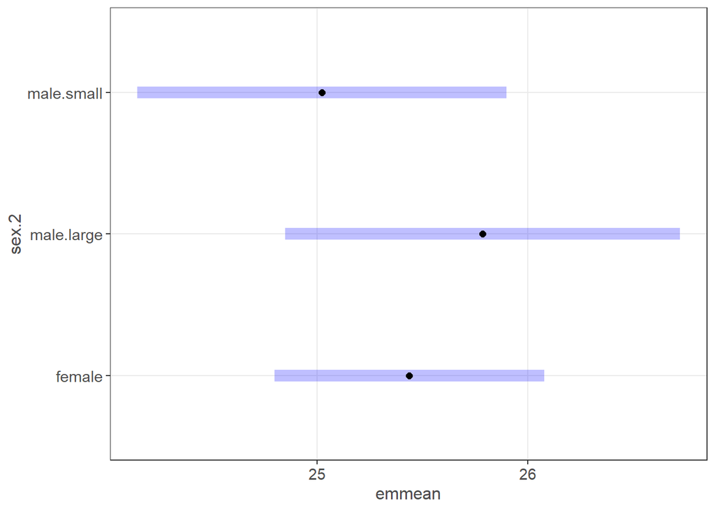

```r
model.6b %>%
  emmeans(pairwise~sex.2) %>%
  plot() #will plot group means with 95% confidence intervals
```